# PML assignment

XU BIN

Sunday, July 19, 2015

### Executive Summary

This assignment is a typical classification problem, since the output has 5 level, General linear model cannot handle this conveniently. So I choose **CART + Random forest/Boost** to solve this . the difficulty is that there are too many variables. if we remain all, the time-complexity is too high. so we need to choose the most valuable component to construct the training data set. At last, I choose 8 covariances to get to about **97%** accuracy.

#### 1. Firstly import “caret” & “rpart” library then load the data file

```r
library(caret)
library(rpart)
### setwd() set the correct working directory
dat <- read.csv("pml-training.csv")
val <- read.csv("pml-testing.csv")
```

#### 2. Data cleaning and split the data into training set and testing set

- Item 1: Remove NA column

```r
dat_cr <- dat[, complete.cases(t(dat))]
```

- Item 2: split the data into training set and testing set

```r
inTrain <- createDataPartition(y=dat_cr$classe, p=0.7, list=FALSE)
training <- dat_cr[inTrain, ]
testing <- dat_cr[-inTrain, ]
```

- Item 3: Remove useless rows from training set

```r
training <- training[, -c(1:7)]
training <- data.frame(Filter(is.numeric, training), classe=training$classe)
```

#### 3. exploratoray analysis

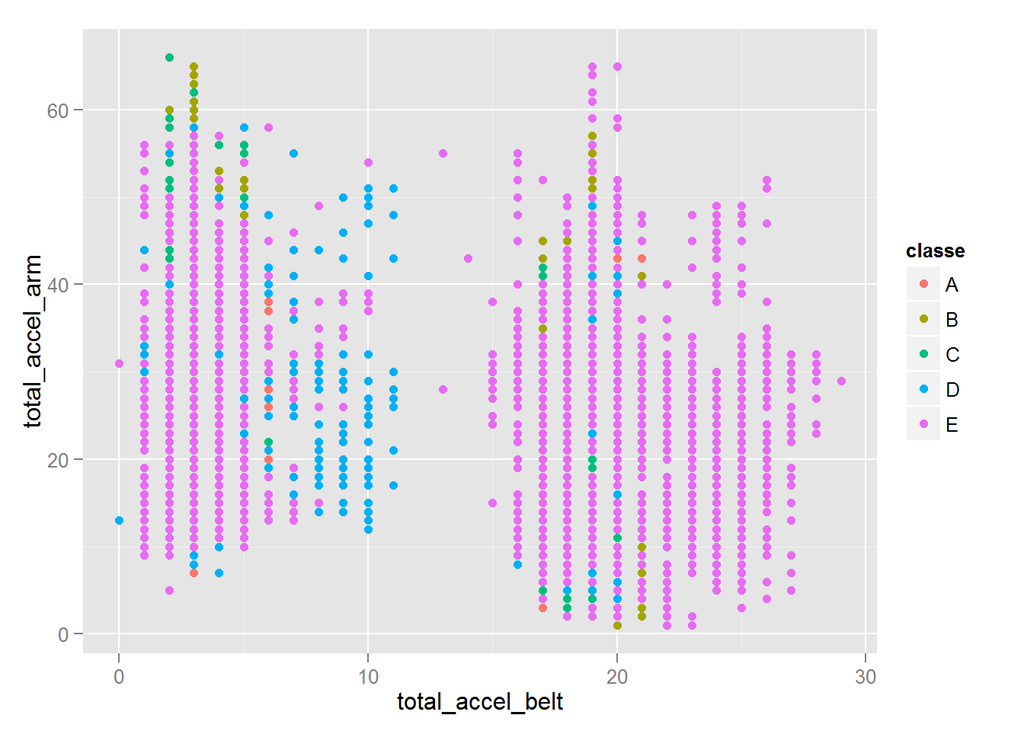

```r
qplot(total_accel_belt, total_accel_arm, colour=classe,data=training)
```

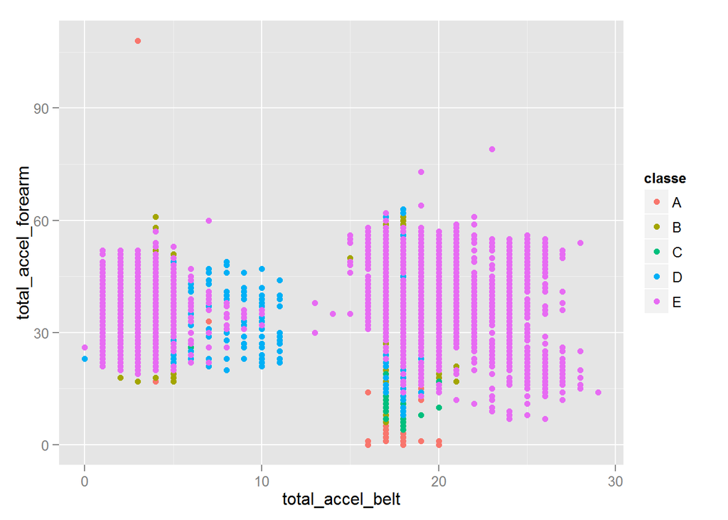

```r
qplot(total_accel_belt, total_accel_forearm,colour=classe,data=training)
```

We found there exist some relationship among total variances and classe and we need to find more

#### 4. General CART

```r
set.seed(38125)
model_cart <- train(classe ~ ., method="rpart", data=training)
pre <- predict(model_cart, testing)
confusionMatrix(pre, testing$classe)
```

```
## Confusion Matrix and Statistics
##
##           Reference
## Prediction    A    B    C    D    E
##          A 1534  483  480  432  165
##          B   27  394   37  180  150
##          C  112  262  509  352  291
##          D    0    0    0    0    0
##          E    1    0    0    0  476
##
## Overall Statistics
##
##                Accuracy : 0.495
##                  95% CI : (0.4821, 0.5078)
##     No Information Rate : 0.2845
##     P-Value [Acc > NIR] : < 2.2e-16
##
##                   Kappa : 0.3394
##  Mcnemar's Test P-Value : NA
##
## Statistics by Class:
##
##                      Class: A Class: B Class: C Class: D Class: E
## Sensitivity            0.9164  0.34592  0.49610   0.0000  0.43993
## Specificity            0.6295  0.91698  0.79070   1.0000  0.99979
## Pos Pred Value         0.4958  0.50000  0.33355      NaN  0.99790
## Neg Pred Value         0.9498  0.85384  0.88139   0.8362  0.88794
## Prevalence             0.2845  0.19354  0.17434   0.1638  0.18386
## Detection Rate         0.2607  0.06695  0.08649   0.0000  0.08088
## Detection Prevalence   0.5257  0.13390  0.25930   0.0000  0.08105
## Balanced Accuracy      0.7730  0.63145  0.64340   0.5000  0.71986
```

The accuracy is about .5 and we need to find the most powerful component that influence the result, so

```r
model_cart$finalModel
```

```
## n= 13737
##
## node), split, n, loss, yval, (yprob)
##       * denotes terminal node
##
##  1) root 13737 9831 A (0.28 0.19 0.17 0.16 0.18)
##    2) roll_belt< 130.5 12569 8676 A (0.31 0.21 0.19 0.18 0.11)
##      4) pitch_forearm< -34 1086    7 A (0.99 0.0064 0 0 0) *
##      5) pitch_forearm>=-34 11483 8669 A (0.25 0.23 0.21 0.2 0.12)
##       10) magnet_dumbbell_y< 438.5 9720 6966 A (0.28 0.18 0.24 0.19 0.11)
##         20) roll_forearm< 123.5 6026 3564 A (0.41 0.18 0.18 0.17 0.059) *
##         21) roll_forearm>=123.5 3694 2476 C (0.079 0.18 0.33 0.23 0.18) *
##       11) magnet_dumbbell_y>=438.5 1763  864 B (0.034 0.51 0.041 0.22 0.19) *
##    3) roll_belt>=130.5 1168   13 E (0.011 0 0 0 0.99) *
```

We found roll_belt, pitch_forearm, magnet_dumbbell_y and roll_forearm is the top 4

### 5. Random Forest

```r
training_2 <- training[, c("roll_belt", "pitch_forearm", "magnet_dumbbell_y", "roll_forearm", "classe")]
model_rf1 <- train(classe ~., method="rf", data=training_2, ntree=50)
pre_rf1 <- predict(model_rf1, testing)
confusionMatrix(pre_rf1, testing$classe)
```

```
## Confusion Matrix and Statistics
##
##           Reference
## Prediction    A    B    C    D    E
##          A 1581   30    6    2    8
##          B   16  949   32   17   33
##          C   62   76  948   54   12
##          D   14   70   31  887    8
##          E    1   14    9    4 1021
##
## Overall Statistics
##
##                Accuracy : 0.9152
##                  95% CI : (0.9078, 0.9222)
##     No Information Rate : 0.2845
##     P-Value [Acc > NIR] : < 2.2e-16
##
##                   Kappa : 0.8929
##  Mcnemar's Test P-Value : < 2.2e-16
##
## Statistics by Class:
##
##                      Class: A Class: B Class: C Class: D Class: E
## Sensitivity            0.9444   0.8332   0.9240   0.9201   0.9436
## Specificity            0.9891   0.9794   0.9580   0.9750   0.9942
## Pos Pred Value         0.9717   0.9064   0.8229   0.8782   0.9733
## Neg Pred Value         0.9782   0.9607   0.9835   0.9842   0.9874
## Prevalence             0.2845   0.1935   0.1743   0.1638   0.1839
## Detection Rate         0.2686   0.1613   0.1611   0.1507   0.1735
## Detection Prevalence   0.2765   0.1779   0.1958   0.1716   0.1782
## Balanced Accuracy      0.9668   0.9063   0.9410   0.9476   0.9689
```

We get the accuracy is .91, it’s much better than CART, but we need to see whether it still can be improved,so we add more covariances into it.

```r
training_3 <- training[, c("roll_belt", "pitch_forearm", "magnet_dumbbell_y", "roll_forearm","total_accel_belt", "total_accel_arm", "total_accel_dumbbell", "total_accel_forearm", "classe")]
model_rf2 <- train(classe ~., method="rf", data=training_3, ntree=50)
pre_rf2 <- predict(model_rf2, testing)
confusionMatrix(pre_rf2, testing$classe)
```

```
## Confusion Matrix and Statistics
##
##           Reference
## Prediction    A    B    C    D    E
##          A 1664   15    4    3    5
##          B    5 1066   22    8   11
##          C    4   26  989   22    7
##          D    1   26    8  926    5
##          E    0    6    3    5 1054
##
## Overall Statistics
##
##                Accuracy : 0.9684
##                  95% CI : (0.9636, 0.9727)
##     No Information Rate : 0.2845
##     P-Value [Acc > NIR] : < 2.2e-16
##
##                   Kappa : 0.96
##  Mcnemar's Test P-Value : 0.0007183
##
## Statistics by Class:
##
##                      Class: A Class: B Class: C Class: D Class: E
## Sensitivity            0.9940   0.9359   0.9639   0.9606   0.9741
## Specificity            0.9936   0.9903   0.9879   0.9919   0.9971
## Pos Pred Value         0.9840   0.9586   0.9437   0.9586   0.9869
## Neg Pred Value         0.9976   0.9847   0.9924   0.9923   0.9942
## Prevalence             0.2845   0.1935   0.1743   0.1638   0.1839
## Detection Rate         0.2828   0.1811   0.1681   0.1573   0.1791
## Detection Prevalence   0.2873   0.1890   0.1781   0.1641   0.1815
## Balanced Accuracy      0.9938   0.9631   0.9759   0.9762   0.9856
```

```r
pre_val_rf1 <- predict(model_rf1, val)
pre_val_rf2 <- predict(model_rf2, val)
result <- data.frame(pre_val_rf1, pre_val_rf2)
result
```

```
##    pre_val_rf1 pre_val_rf2
## 1            B           B
## 2            A           A
## 3            B           B
## 4            C           A
## 5            A           A
## 6            E           E
## 7            D           D
## 8            B           B
## 9            A           A
## 10           A           A
## 11           B           B
## 12           C           C
## 13           B           B
## 14           A           A
## 15           E           E
## 16           E           E
## 17           A           A
## 18           D           B
## 19           A           B
## 20           B           B
```

So we can most of them are the same and it’s logical.